# Изучение закономерностей, определяющих успешность игр

### 3.5. Построим график «ящик с усами» по глобальным продажам игр в разбивке по платформам.

К плану работ

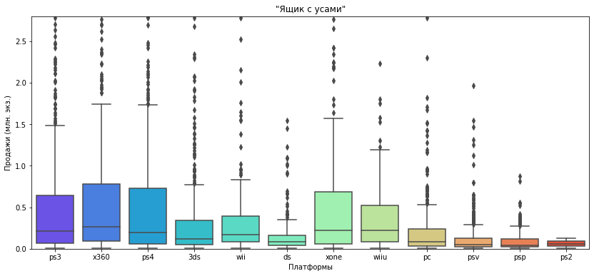

```python
# строим график "ящик с усами"
f, ax = plt.subplots(figsize=(14, 6))
sns.boxplot(x='platform', y='total_sales', data=data_actual_period, palette='rainbow')
ax.set(xlabel='Платформы',
       ylabel='Продажи (млн. экз.)',
       ylim = (0, 2.8),
       title='"Ящик с усами"')
plt.show()
```

```python
#Посчитаем уровень редких и выбиающихся значений для каждой из платформ
for elem in data_actual_period['platform'].unique():
    data_tmp = data_actual_period[data_actual_period['platform'] == elem]
    Q1 = data_tmp['total_sales'].quantile(0.25)
    Q3 = data_tmp['total_sales'].quantile(0.75)
    IQR = Q3 - Q1
    data4 = data2[(data2['platform'] == elem) & (data2['total_sales'] <= (Q3+1.5*IQR))]
    print('Редкие и выбивающиеся значения для ', elem,': больше ', round((Q3+1.5*IQR), 2), 'млн.')
```

```
Редкие и выбивающиеся значения для  ps3 : больше  1.5 млн.
Редкие и выбивающиеся значения для  x360 : больше  1.82 млн.
Редкие и выбивающиеся значения для  ps4 : больше  1.74 млн.
Редкие и выбивающиеся значения для  3ds : больше  0.77 млн.
Редкие и выбивающиеся значения для  wii : больше  0.86 млн.
Редкие и выбивающиеся значения для  ds : больше  0.35 млн.
Редкие и выбивающиеся значения для  xone : больше  1.62 млн.
Редкие и выбивающиеся значения для  wiiu : больше  1.19 млн.
Редкие и выбивающиеся значения для  pc : больше  0.54 млн.
Редкие и выбивающиеся значения для  psv : больше  0.3 млн.
Редкие и выбивающиеся значения для  psp : больше  0.27 млн.
Редкие и выбивающиеся значения для  ps2 : больше  0.17 млн.
```

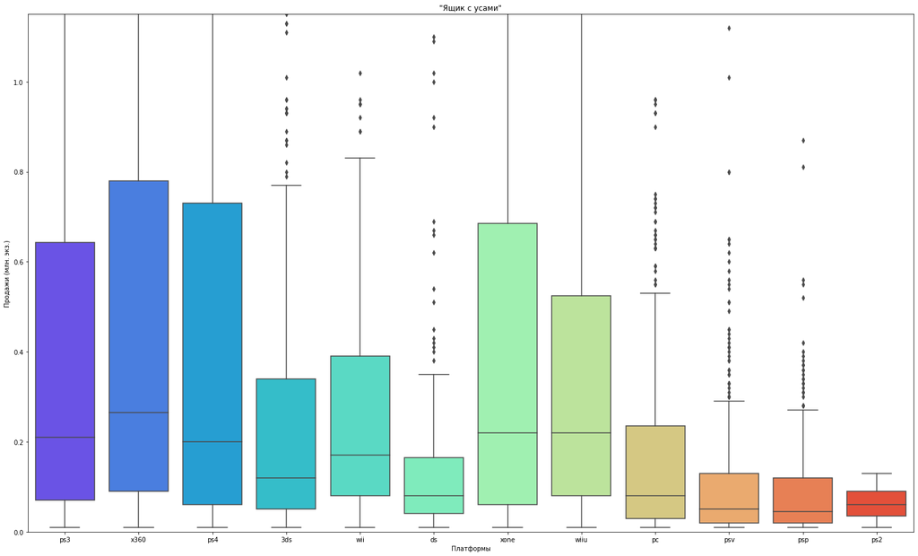

```python
# построим ящик с усами укрупненно чтобы было видно уровень медианы и квартилей
f, ax = plt.subplots(figsize=(25, 15))
sns.boxplot(x='platform', y='total_sales', data=data_actual_period, palette='rainbow')
ax.set(xlabel='Платформы',
       ylabel='Продажи (млн. экз.)',
       ylim = (0, 1.15),
       title='"Ящик с усами"')
plt.show()
```

#### Вывод:

Платформы продажи игр на которые медианно в мире не превышает 100 тыс копий - это ps2, psp, psv, pc, ds - закупать их бесперспективно,  
исклчением может быть лишь pc - как отдельная категория платформы  
Платформы ps3, x360, ps4, xone, wiiu - продажи медианно выше 0,2 млн - их можно закупать, упор на лидеров ps4 и xone.  
игры на платформах 3ds и wii - закупать только лидирующие позиции